# Predicting NBA Game-level Results via a Machine-Learning Pipeline

DATA 607 - Data Science in Context Presentation

Author

Kailot C. Harris

Published

September 21, 2026

## Agenda

1. **Data Pipeline and Rolling Metrics**
2. **Machine Learning Workflow**
3. **Findings and Model Evaluation**

## Background and Motivation

**Inspiration:**

‘Exploring Machine Learning: Predicting the NBA’ by author Kishore Annambhotla.

https://medium.com/@k4annam/exploring-machine-learning-predicting-the-nba-607aea31c955

**Objective:**

Build a Machine Learning pipeline using real-time data to predict NBA game outcomes.

**R Packages utilized:**

`hoopR`, `tidyverse`, `slider`, and `tidymodels`

## Data and Feature Engineering

**Data Source:**

*Game-level box score data from `hoopR` package (2019-2026 seasons)*

```r
box_scores <- hoopR::load_nba_team_box(seasons = 2019:2026)
```

**Rolling Metrics:**

*18-game rolling averages are computed for:*

— Offensive output and shooting metrics (Effective FG%, True Shooting %)

— Advanced box stats (Rebounds, Assists, Turnovers, Steals, Blocks)

**Contextual factors:**

*Days of rest and home court advantage (HCA)*

**Click to view feature engineering R code**

```r
#Empirically derived rolling-calc-window
n_rolling_days <- 18

full_features_df <- box_scores |>
  arrange(team_id, game_date) |>
  group_by(team_id) |>
  mutate(
    #define home-game advantage
    hga = if_else(str_detect(team_home_away, "away"),0,1),

    #define last game outcome
    lgo = lag(as.integer(team_winner), n = 1, default = NA),

    #define effective field goal percentage
    efg = (field_goals_made + 0.5*three_point_field_goals_made)/(field_goals_attempted),

    #define turnover rate percentage
    tov = (total_turnovers)/(field_goals_attempted + 0.44 * free_throws_attempted + total_turnovers),

    #define free throw rate
    ftr = free_throws_attempted/field_goals_attempted,

    #define true shooting percentage
    ts = team_score / (2* (field_goals_attempted + (0.44 * free_throws_attempted))),

    # Rolling n-game average of offensive rating and shooting %
    roll_pts_scored = slide_dbl(team_score, mean, .before = n_rolling_days, .after = -1),
    roll_field_goal_pct = slide_dbl(field_goal_pct, mean, .before = n_rolling_days, .after = -1),
    roll_oreb = slide_dbl(offensive_rebounds, mean, .before = n_rolling_days, .after = -1),
    roll_dreb = slide_dbl(defensive_rebounds, mean, .before = n_rolling_days, .after = -1),
    roll_reb = slide_dbl(total_rebounds, mean, .before = n_rolling_days, .after = -1),
    roll_ast = slide_dbl(assists, mean, .before = n_rolling_days, .after = -1),
    roll_stl = slide_dbl(steals, mean, .before = n_rolling_days, .after = -1),
    roll_blk = slide_dbl(blocks, mean, .before = n_rolling_days, .after = -1),
    roll_tov = slide_dbl(turnovers, mean, .before = n_rolling_days, .after = -1),
    roll_efg = slide_dbl(efg, mean, .before = n_rolling_days, .after = -1),
    roll_tovp = slide_dbl(tov, mean, .before = n_rolling_days, .after = -1),
    roll_ftr = slide_dbl(ftr, mean, .before = n_rolling_days, .after = -1),
    roll_ts = slide_dbl(ts, mean, .before = n_rolling_days, .after = -1),

    days_rest = as.numeric(game_date - lag(game_date))
  ) |>
  ungroup()
```

## Machine Learning Pipeline

**Train/Test split:**

— *Training: Historical seasons (2019-2025)*

— *Testing: 2026 season*

**Tidymodels Recipe:**

*Data normalization, feature disentanglement, and removal of collinear variables (i.e. non-independent)*

**Algorithm:**

*Random forest classification model (`ranger`) with 500 trees, evaluating Gini impurity*

```r
rf_spec <- rand_forest(trees=500, mode = "classification") |>
  set_engine("ranger", importance = "impurity")
```

```r
nba_workflow <- workflow() |>
  add_recipe(nba_recipe) |>
  add_model(rf_spec)

nba_fit <- fit(nba_workflow, data = train_data)
```

## Findings and Model Evaluation

**2026 Season Metrics:**

- **Accuracy:** 63%

(compared to 50% random baseline)

- **ROC-AUC:** 0.669

**Key Drivers:**  
* Differential TS%  
* Differential eFG%

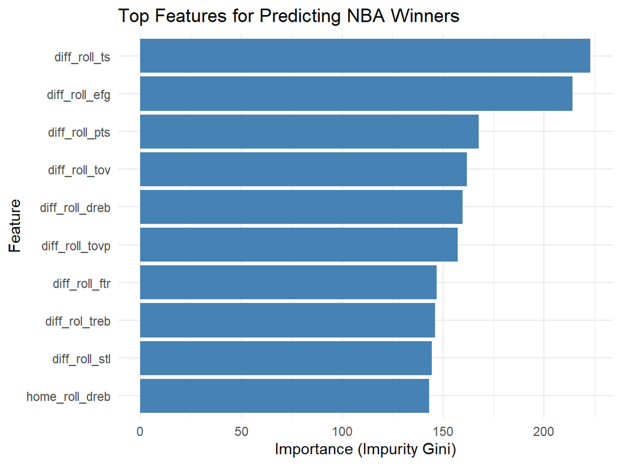

## 2027 NBA Regular Season Predictions

[output not shown]

## Monte Carlo Simulation Results

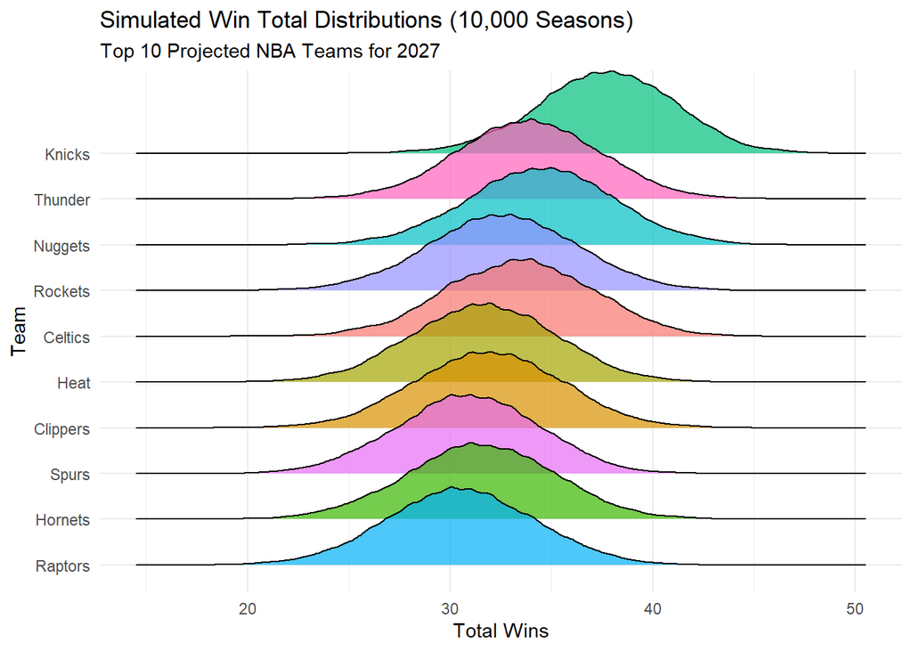

## Summary and Conclusions

**Summary:**

- **An end-to-end Machine Learning pipeline was built using Random Forest classification**
- **Achieved an accuracy of 63% on 2026 NBA Season game-level predictions**

**Takeaways:**

- *Rolling features capture team momentum better than static seasonal stats.*
- *Random Forest methodology provides a stable probability estimate for game outcomes.*

**Next steps:**

- *Player-level tracking, injury awareness, XGBoost comparison, and star match-up differentials.*

## Citations and Acknowledgements

- **Medium article on NBA predictions using ML:**

— *https://medium.com/@k4annam/exploring-machine-learning-predicting-the-nba-607aea31c955*

- **Core R Packages:**

— *`tidymodels`, `hoopR`, `slider`, and `tidyverse`*

— *`hoopR` package: https://hoopr.sportsdataverse.org*

- *Code structuring and `tidymodels` syntax debugging were assisted by Google Gemini (Flash model 3.6, 2026).*

— *All logic, data pipeline design, and outputs were verified by the author.*